# Mizrahi Lakan, S., Millgram, Y., & Tamir, M. (2023).

Desired sadness, happiness, fear and calmness in depression: The potential roles of valence and arousal. Emotion, 23(4), 1130–1140. https://doi.org/10.1037/emo0001120.supp

Last update at: 2023-07-11

Back to index

# Abstract / Key Points

Studies have demonstrated that depressed individuals want to feel relatively more sadness and less happiness than nondepressed indi- viduals do (Arens & Stangier, 2020; Millgram et al., 2015, 2019; Yoon et al., 2020). What underlies such motivations, however, is still unclear, partly because research to date has focused exclu- sively on sadness and happiness.

What dimension do they desire? Valence? Arousal? Discrete emotions?

We replicated prior findings, such that across measures, depressed individuals were relatively more motivated to feel sadness than nondepressed individuals were. Furthermore, whereas nondepressed individuals were motivated to listen to music clips and experience emotions that were positive (vs. negative) in valence, this was not necessarily the case among depressed individuals. Compared to nondepressed individuals, depressed individuals desired music that was relatively lower (vs. higher) in arousal, but reported a relatively stronger desire for negative (vs. positive) emotions.

Everyone shows a preference for calm music (low arousal, positive)

Method:

- Participants: 36 in each group (depressed group was selected with clinical interview)
- Music selection task (p.1133)
  - 54 unique pairs ($4\choose{2}$ (two emotions) *$3\choose{1}$* (one of the three clips of an emotion) $3\choose{1}$ (one of the three clips of the other emotion) = 54)
  - each comparison appears 9 times (e.g., sad vs. calm) —> DV: the percetage participants chose an emotion
- Self-report of desired emotions
  - the degree to which hey generally wanted to experience various emotions (1 = not at all, 7 = extremely)
  - sadness: sad, downhearted, depressed
  - happiness: happy, joyful, lighthearted
  - fear: scared, worried, jittery
  - calmness: clam, relaxed, serene

What the comparison is based on is important!

- Between-group comparison
  - Music: Depressed vs. non-depressed: more sad, less happy, equal on fear and on calm
  - Self-report: Depressed vs. non-depressed: more sad, fear, equal on happiness and calmness
- Within-depression group
  - Music: more calm than sad = happy, and fear least
  - Self-report: (both groups) more calmness > sadness and calmness > fear; happiness > sadness
    - Also a main effect of group —> Overall, depressed participants had stronger desires for all emotions than non-depressed groups
      - 4.07 (.06) > 3.87 (.06)

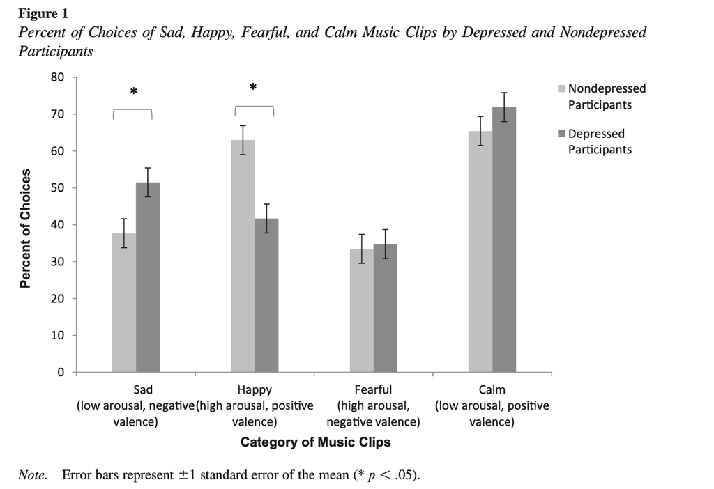

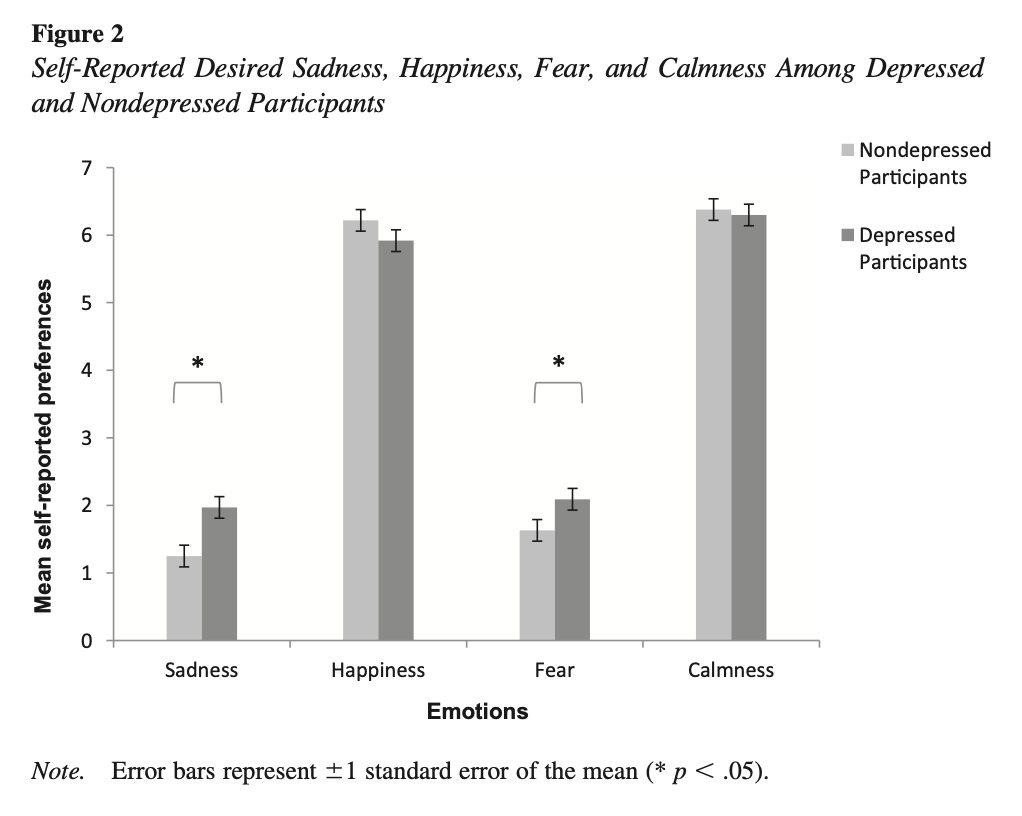

Back to index